# model2_cv

Xinyi Lin

12/15/2018

### Load Main dataset

```r
cancer_reg = read_csv("./data/Cancer_Registry.csv") %>%
  janitor::clean_names() %>%
  dplyr::select(target_death_rate, everything()) %>%
  separate(geography, into = c("county", "state"), sep = ", ") %>%
  mutate(
    avg_deaths_per_year = as.numeric(avg_deaths_per_year),
    med_income = as.numeric(med_income),
    pop_est2015 = as.numeric(med_income),
    county = str_replace(county, " ", ""))
```

### 1. Remove Categorical and high proportion missing values

- Remove state and county - catergorical parameters related to observations
- Remove avg_ann_count and avg_deaths_per_year, since this data is already captured in mortality rate and incidence, weighted by county population.
- Remove variables with high percentage missing values:
  - pct_employed16_over - 152 missing. This variable has some collinearity with pct_unemployed16_over (R = -0.65), so we are not completely excluding information related to employment.
  - pct_some_col18_24 - 2285 missing. Over 2/3 missing values.
  - pct_private_coverage_alone - 609 missing. Since this variable has strong collinearity with pct_private_coverage (R = 0.93), so we are not excluding valuable information on insurance coverage

```r
# Examine missing values
# 3 variables with high missing: values pct_employed16_over (152), pct_some_col18_24 (2285), pct_private_coverage_alone (609)
skimr::skim(cancer_reg)
```

```
## Skim summary statistics
##  n obs: 3047
##  n variables: 35
##
## ── Variable type:character ───────────────────────────────────────────────────────────────────────────────────────────────────────
##    variable missing complete    n min max empty n_unique
##  binned_inc       0     3047 3047  16  18     0       10
##      county       0     3047 3047   9  30     0     1819
##       state       0     3047 3047   4  20     0       51
##
## ── Variable type:numeric ─────────────────────────────────────────────────────────────────────────────────────────────────────────
##                    variable missing complete    n     mean       sd
##               avg_ann_count       0     3047 3047   606.34  1416.36
##         avg_deaths_per_year       0     3047 3047   185.97   504.13
##          avg_household_size       0     3047 3047     2.48     0.43
##                  birth_rate       0     3047 3047     5.64     1.99
##              incidence_rate       0     3047 3047   448.27    54.56
##                  med_income       0     3047 3047 47063.28 12040.09
##                  median_age       0     3047 3047    45.27    45.3
##           median_age_female       0     3047 3047    42.15     5.29
##             median_age_male       0     3047 3047    39.57     5.23
##                   pct_asian       0     3047 3047     1.25     2.61
##           pct_bach_deg18_24       0     3047 3047     6.16     4.53
##         pct_bach_deg25_over       0     3047 3047    13.28     5.39
##                   pct_black       0     3047 3047     9.11    14.53
##       pct_emp_priv_coverage       0     3047 3047    41.2      9.45
##         pct_employed16_over     152     2895 3047    54.15     8.32
##                 pct_hs18_24       0     3047 3047    35        9.07
##               pct_hs25_over       0     3047 3047    34.8      7.03
##      pct_married_households       0     3047 3047    51.24     6.57
##              pct_no_hs18_24       0     3047 3047    18.22     8.09
##              pct_other_race       0     3047 3047     1.98     3.52
##        pct_private_coverage       0     3047 3047    64.35    10.65
##  pct_private_coverage_alone     609     2438 3047    48.45    10.08
##         pct_public_coverage       0     3047 3047    36.25     7.84
##   pct_public_coverage_alone       0     3047 3047    19.24     6.11
##           pct_some_col18_24    2285      762 3047    40.98    11.12
##       pct_unemployed16_over       0     3047 3047     7.85     3.45
##                   pct_white       0     3047 3047    83.65    16.38
##             percent_married       0     3047 3047    51.77     6.9
```

[output cut: 22 more lines]

```
##     22.99     47.76    51.67    55.4      78.08 ▁▁▂▆▇▂▁▁
##      0        12.8     17.1     22.7      64.1  ▂▇▇▃▁▁▁▁
##      0         0.3      0.83     2.18     41.93 ▇▁▁▁▁▁▁▁
##     22.3      57.2     65.1     72.1      92.3  ▁▁▂▅▇▇▅▁
##     15.7      41       48.7     55.6      78.9  ▁▁▅▇▇▅▂▁
##     11.2      30.9     36.3     41.55     65.1  ▁▂▅▇▇▃▁▁
##      2.6      14.85    18.8     23.1      46.6  ▁▃▇▇▃▁▁▁
##      7.1      34       40.4     46.4      79    ▁▁▅▇▅▂▁▁
##      0.4       5.5      7.6      9.7      29.4  ▂▇▇▂▁▁▁▁
##     10.2      77.3     90.06    95.45    100    ▁▁▁▁▁▂▃▇
##     23.1      47.75    52.4     56.4      72.5  ▁▁▁▅▇▇▂▁
##  22640     38882.5  45207    52492    125635    ▂▇▅▁▁▁▁▁
##      3.2      12.15    15.9     20.4      47.4  ▂▇▇▅▂▁▁▁
##      0         0        0       83.65   9762.31 ▇▁▁▁▁▁▁▁
##     59.7     161.2    178.1    195.2     362.8  ▁▁▆▇▂▁▁▁
```

```r
# observe collinearity between pct_private_coverage and variable to exclude, pct_private_coverage_alone
cancer_reg %>%
  dplyr::select(target_death_rate, pct_private_coverage, pct_private_coverage_alone) %>% cor(x = ., use = "pairwise.complete.obs")
```

```
##                            target_death_rate pct_private_coverage
## target_death_rate                  1.0000000           -0.3860655
## pct_private_coverage              -0.3860655            1.0000000
## pct_private_coverage_alone        -0.3637037            0.9334958
##                            pct_private_coverage_alone
## target_death_rate                          -0.3637037
## pct_private_coverage                        0.9334958
## pct_private_coverage_alone                  1.0000000
```

```r
# observe collinearity between pct_unemployed16_over and variable to exclude, pct_employed16_over
cancer_reg %>%
  dplyr::select(target_death_rate, pct_unemployed16_over, pct_employed16_over) %>% cor(x = ., use = "pairwise.complete.obs")
```

```
##                       target_death_rate pct_unemployed16_over
## target_death_rate             1.0000000             0.3784124
## pct_unemployed16_over         0.3784124             1.0000000
## pct_employed16_over          -0.4120458            -0.6481142
##                       pct_employed16_over
## target_death_rate              -0.4120458
## pct_unemployed16_over          -0.6481142
## pct_employed16_over             1.0000000
```

```r
# remove variables with high missing values, county and state
cancer_reg_tidy = cancer_reg %>%
  dplyr::select(-pct_employed16_over, -pct_some_col18_24, -pct_private_coverage_alone, -county, -state, -avg_ann_count, -avg_deaths_per_year)
```

### 2. Remove Variables with high Collinearity

Next, we will examine collinearity between remaining variables. Remove the following:

- med_income - CL with pct_bach_deg25_over
- pop_est2015 - CL with poverty_percent (-0.79)
- poverty_percent - CL with pct_public_coverage_alone (0.798)
- percent_married - CL with pct_married_households (0.87)
- pct_hs25_over - CL with pct_bach_deg25_over (-0.74)
- Only keep “pct_public_coverage_alone” - out of all insurance variables, this has highest correlation with main outcome. High CL between between all insurance variables.

Other variables of consideration. * pct_white and pct_black has high CL (-0.83), but from a demographic standpoint, we may be interested in keeping both. * create pct_nonwhite as a proxy * discuss why pct_black and pct_white has such negative correlation in report

```r
# Examine collinearity between variables
cor_df = cancer_reg_tidy %>%
  dplyr::select(-binned_inc) %>%
  cor()

# remove collinear variables
# remove variables due to missing values
# remove variables due to collinearity
# create proxy variable pct_nonwhite
cancer_reg_tidy = cancer_reg %>%
  dplyr::select(
    -pct_employed16_over, -pct_some_col18_24, -pct_private_coverage_alone, -county, -state, -avg_ann_count, -avg_deaths_per_year) %>%
  dplyr::select(
    -med_income, -median_age_female, -pct_emp_priv_coverage, -pct_public_coverage, -pct_private_coverage, -pop_est2015, -poverty_percent, -pct_hs25_over, -percent_married, -binned_inc) %>%
  mutate(pct_nonwhite = 1 - pct_white)

skimr::skim(cancer_reg_tidy)
```

```
## Skim summary statistics
##  n obs: 3047
##  n variables: 19
##
## ── Variable type:numeric ─────────────────────────────────────────────────────────────────────────────────────────────────────────
##                   variable missing complete    n   mean     sd      p0
##         avg_household_size       0     3047 3047   2.48   0.43   0.022
##                 birth_rate       0     3047 3047   5.64   1.99   0
##             incidence_rate       0     3047 3047 448.27  54.56 201.3
##                 median_age       0     3047 3047  45.27  45.3   22.3
##            median_age_male       0     3047 3047  39.57   5.23  22.4
##                  pct_asian       0     3047 3047   1.25   2.61   0
##          pct_bach_deg18_24       0     3047 3047   6.16   4.53   0
##        pct_bach_deg25_over       0     3047 3047  13.28   5.39   2.5
##                  pct_black       0     3047 3047   9.11  14.53   0
##                pct_hs18_24       0     3047 3047  35      9.07   0
##     pct_married_households       0     3047 3047  51.24   6.57  22.99
##             pct_no_hs18_24       0     3047 3047  18.22   8.09   0
##               pct_nonwhite       0     3047 3047 -82.65  16.38 -99
##             pct_other_race       0     3047 3047   1.98   3.52   0
##  pct_public_coverage_alone       0     3047 3047  19.24   6.11   2.6
##      pct_unemployed16_over       0     3047 3047   7.85   3.45   0.4
##                  pct_white       0     3047 3047  83.65  16.38  10.2
##              study_per_cap       0     3047 3047 155.4  529.63   0
##          target_death_rate       0     3047 3047 178.66  27.75  59.7
##     p25    p50    p75    p100     hist
##    2.37   2.5    2.63    3.97 ▁▁▁▁▇▇▁▁
##    4.52   5.38   6.49   21.33 ▁▇▇▂▁▁▁▁
##  420.3  453.55 480.85 1206.9  ▁▇▇▁▁▁▁▁
##   37.7   41     44     624    ▇▁▁▁▁▁▁▁
##   36.35  39.6   42.5    64.7  ▁▂▆▇▃▁▁▁
##    0.25   0.55   1.22   42.62 ▇▁▁▁▁▁▁▁
##    3.1    5.4    8.2    51.8  ▇▅▁▁▁▁▁▁
##    9.4   12.3   16.1    42.2  ▂▇▆▃▁▁▁▁
##    0.62   2.25  10.51   85.95 ▇▁▁▁▁▁▁▁
##   29.2   34.7   40.7    72.5  ▁▁▃▇▆▂▁▁
##   47.76  51.67  55.4    78.08 ▁▁▂▆▇▂▁▁
##   12.8   17.1   22.7    64.1  ▂▇▇▃▁▁▁▁
##  -94.45 -89.06 -76.3    -9.2  ▇▃▂▁▁▁▁▁
##    0.3    0.83   2.18   41.93 ▇▁▁▁▁▁▁▁
##   14.85  18.8   23.1    46.6  ▁▃▇▇▃▁▁▁
##    5.5    7.6    9.7    29.4  ▂▇▇▂▁▁▁▁
##   77.3   90.06  95.45  100    ▁▁▁▁▁▂▃▇
##    0      0     83.65 9762.31 ▇▁▁▁▁▁▁▁
##  161.2  178.1  195.2   362.8  ▁▁▆▇▂▁▁▁
```

### 3. Variables to Transform IGNORE FOR NOW

1. med_income, poverty_percent. Keep *poverty_percent*, stronger linear rel with explanatory variable

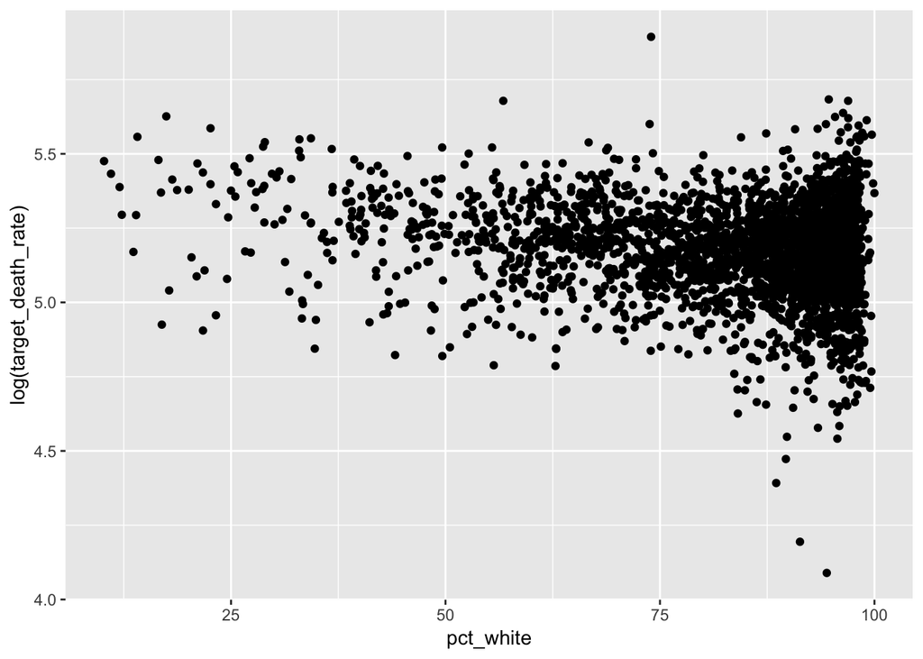

```r
# scatterplot b/w variables
cancer_reg %>%
  ggplot(aes(x = pct_white, y = log(target_death_rate))) +
  geom_point()
```

### 1. Automatic Procedures

10-predictor Model: Step: AIC=18159.4 Adjusted R-squared: 0.4986 target_death_rate ~ pct_bach_deg25_over + incidence_rate + pct_public_coverage_alone + pct_other_race + pct_white + pct_hs18_24 + median_age_male + birth_rate + pct_married_households + pct_unemployed16_over

### 2. Criterion Based Procedures

10-parameters model: lm(formula = target_death_rate ~ incidence_rate + median_age_male + pct_hs18_24 + pct_bach_deg25_over + pct_unemployed16_over + pct_public_coverage_alone + pct_other_race + pct_married_households + birth_rate, data = cancer_reg_tidy)

8-parameters model: lm(formula = target_death_rate ~ incidence_rate + median_age_male + pct_bach_deg25_over + pct_hs18_24 + pct_public_coverage_alone + pct_other_race + pct_married_households, data = cancer_reg_tidy)

```r
cancer_reg_cp =
  cancer_reg %>%
  as.data.frame() %>%
  dplyr::select(target_death_rate, pct_bach_deg25_over, incidence_rate, pct_married_households, pct_hs18_24, pct_other_race, median_age_male, birth_rate, pct_public_coverage_alone, percent_married, pct_unemployed16_over, pct_white)

leaps(x = cancer_reg_cp[,2:12], y = cancer_reg_cp[,1], nbest=1, method="Cp")
```

```
## $which
##       1     2     3     4     5     6     7     8     9     A     B
## 1  TRUE FALSE FALSE FALSE FALSE FALSE FALSE FALSE FALSE FALSE FALSE
## 2  TRUE  TRUE FALSE FALSE FALSE FALSE FALSE FALSE FALSE FALSE FALSE
## 3  TRUE  TRUE FALSE FALSE FALSE FALSE FALSE  TRUE FALSE FALSE FALSE
## 4  TRUE  TRUE FALSE FALSE  TRUE FALSE FALSE  TRUE FALSE FALSE FALSE
## 5  TRUE  TRUE FALSE FALSE  TRUE FALSE FALSE  TRUE FALSE FALSE  TRUE
## 6  TRUE  TRUE  TRUE  TRUE  TRUE FALSE FALSE  TRUE FALSE FALSE FALSE
## 7  TRUE  TRUE  TRUE  TRUE  TRUE  TRUE FALSE  TRUE FALSE FALSE FALSE
## 8  TRUE  TRUE  TRUE  TRUE  TRUE  TRUE  TRUE  TRUE FALSE FALSE FALSE
## 9  TRUE  TRUE  TRUE  TRUE  TRUE  TRUE  TRUE  TRUE FALSE  TRUE FALSE
## 10 TRUE  TRUE  TRUE  TRUE  TRUE  TRUE  TRUE  TRUE  TRUE  TRUE FALSE
## 11 TRUE  TRUE  TRUE  TRUE  TRUE  TRUE  TRUE  TRUE  TRUE  TRUE  TRUE
##
## $label
##  [1] "(Intercept)" "1"           "2"           "3"           "4"
##  [6] "5"           "6"           "7"           "8"           "9"
## [11] "A"           "B"
##
## $size
##  [1]  2  3  4  5  6  7  8  9 10 11 12
##
## $Cp
##  [1] 1626.41303  492.42636  283.95635  210.65081  147.60996  105.16394
##  [7]   61.06313   35.03585   29.12538   16.75942   12.00000
```

### Cross validation

```r
model_10 = lm(formula = target_death_rate ~ pct_bach_deg25_over + incidence_rate + pct_public_coverage_alone + pct_other_race + pct_white + pct_hs18_24 + median_age_male + birth_rate + pct_married_households + pct_unemployed16_over, data = cancer_reg_tidy)

model_9 = lm(formula = target_death_rate ~ incidence_rate + median_age_male + pct_hs18_24 + pct_bach_deg25_over + pct_unemployed16_over + pct_public_coverage_alone + pct_other_race + pct_married_households + birth_rate, data = cancer_reg_tidy)

model_7 = lm(formula = target_death_rate ~ incidence_rate + median_age_male + pct_bach_deg25_over + pct_hs18_24 + pct_public_coverage_alone + pct_other_race + pct_married_households, data = cancer_reg_tidy)
```

### 1. 10-fold cv

```r
train_data_10 = trainControl(method = "cv", number = 10)

# Fit the 4-variables model that we discussed in previous lectures
model_caret10_10 =
  train(target_death_rate ~ pct_bach_deg25_over + incidence_rate + pct_public_coverage_alone + pct_other_race + pct_white + pct_hs18_24 + median_age_male + birth_rate + pct_married_households + pct_unemployed16_over,
    data = cancer_reg_tidy,
    trControl = train_data_10,
    method = 'lm',
    na.action = na.pass)

model_caret10_9 =
  train(target_death_rate ~ incidence_rate + median_age_male + pct_hs18_24 + pct_bach_deg25_over + pct_unemployed16_over + pct_public_coverage_alone + pct_other_race + pct_married_households + birth_rate,
    data = cancer_reg_tidy,
    trControl = train_data_10,
    method = 'lm',
    na.action = na.pass)

model_caret10_7 =
  train(target_death_rate ~ incidence_rate + median_age_male + pct_bach_deg25_over + pct_hs18_24 + pct_public_coverage_alone + pct_other_race + pct_married_households,
    data = cancer_reg_tidy,
    trControl = train_data_10,
    method = 'lm',
    na.action = na.pass)

model_caret10_10
```

```
## Linear Regression
##
## 3047 samples
##   10 predictor
##
## No pre-processing
## Resampling: Cross-Validated (10 fold)
## Summary of sample sizes: 2743, 2743, 2742, 2743, 2741, 2741, ...
## Resampling results:
##
##   RMSE      Rsquared   MAE
##   19.73081  0.4962516  14.697
##
## Tuning parameter 'intercept' was held constant at a value of TRUE
```

```r
#  RMSE     Rsquared   MAE
#  19.7024  0.4938789  14.68475

model_caret10_9
```

```
## Linear Regression
##
## 3047 samples
##    9 predictor
##
## No pre-processing
## Resampling: Cross-Validated (10 fold)
## Summary of sample sizes: 2742, 2742, 2743, 2742, 2743, 2742, ...
## Resampling results:
##
##   RMSE      Rsquared   MAE
##   19.70285  0.4956401  14.67017
##
## Tuning parameter 'intercept' was held constant at a value of TRUE
```

```r
#  RMSE      Rsquared   MAE
#  19.68147  0.4967687  14.66503

model_caret10_7
```

```
## Linear Regression
##
## 3047 samples
##    7 predictor
##
## No pre-processing
## Resampling: Cross-Validated (10 fold)
## Summary of sample sizes: 2743, 2742, 2741, 2742, 2743, 2743, ...
## Resampling results:
##
##   RMSE      Rsquared   MAE
##   19.78598  0.4906512  14.82969
##
## Tuning parameter 'intercept' was held constant at a value of TRUE
```

```r
#  RMSE      Rsquared   MAE
#  19.79374  0.4900993  14.82677
```

### 1. 5-fold cv

```r
train_data_5 = trainControl(method = "cv", number = 5)

# Fit the 4-variables model that we discussed in previous lectures
model_caret5_10 =
  train(target_death_rate ~ pct_bach_deg25_over + incidence_rate + pct_public_coverage_alone + pct_other_race + pct_white + pct_hs18_24 + median_age_male + birth_rate + pct_married_households + pct_unemployed16_over,
    data = cancer_reg_tidy,
    trControl = train_data_5,
    method = 'lm',
    na.action = na.pass)

model_caret5_9 =
  train(target_death_rate ~ incidence_rate + median_age_male + pct_hs18_24 + pct_bach_deg25_over + pct_unemployed16_over + pct_public_coverage_alone + pct_other_race + pct_married_households + birth_rate,
    data = cancer_reg_tidy,
    trControl = train_data_5,
    method = 'lm',
    na.action = na.pass)

model_caret5_7 =
  train(target_death_rate ~ incidence_rate + median_age_male + pct_bach_deg25_over + pct_hs18_24 + pct_public_coverage_alone + pct_other_race + pct_married_households,
    data = cancer_reg_tidy,
    trControl = train_data_5,
    method = 'lm',
    na.action = na.pass)

model_caret5_10
```

```
## Linear Regression
##
## 3047 samples
##   10 predictor
##
## No pre-processing
## Resampling: Cross-Validated (5 fold)
## Summary of sample sizes: 2438, 2438, 2438, 2437, 2437
## Resampling results:
##
##   RMSE    Rsquared   MAE
##   19.759  0.4930734  14.70626
##
## Tuning parameter 'intercept' was held constant at a value of TRUE
```

```r
#  RMSE      Rsquared   MAE
#  19.70115  0.4967758  14.65786

model_caret5_9
```

```
## Linear Regression
##
## 3047 samples
##    9 predictor
##
## No pre-processing
## Resampling: Cross-Validated (5 fold)
## Summary of sample sizes: 2439, 2438, 2438, 2437, 2436
## Resampling results:
##
##   RMSE      Rsquared   MAE
##   19.73321  0.4947043  14.69179
##
## Tuning parameter 'intercept' was held constant at a value of TRUE
```

```r
#  RMSE      Rsquared   MAE
#  19.69373  0.4956894  14.66347

model_caret5_7
```

```
## Linear Regression
##
## 3047 samples
##    7 predictor
##
## No pre-processing
## Resampling: Cross-Validated (5 fold)
## Summary of sample sizes: 2438, 2438, 2438, 2437, 2437
## Resampling results:
##
##   RMSE      Rsquared   MAE
##   19.80027  0.4920641  14.82359
##
## Tuning parameter 'intercept' was held constant at a value of TRUE
```

```r
#  RMSE      Rsquared   MAE
#  19.82486  0.4890669  14.84762
```

Since three models have similar performance in cross validation, based on ‘principle of parsimony’, we chose models with 7 predictors.

Final model: `lm(formula = target_death_rate ~ incidence_rate + median_age_male + pct_hs18_24 + pct_bach_deg25_over + pct_public_coverage_alone + pct_other_race + pct_married_households, data = cancer_reg_tidy)`

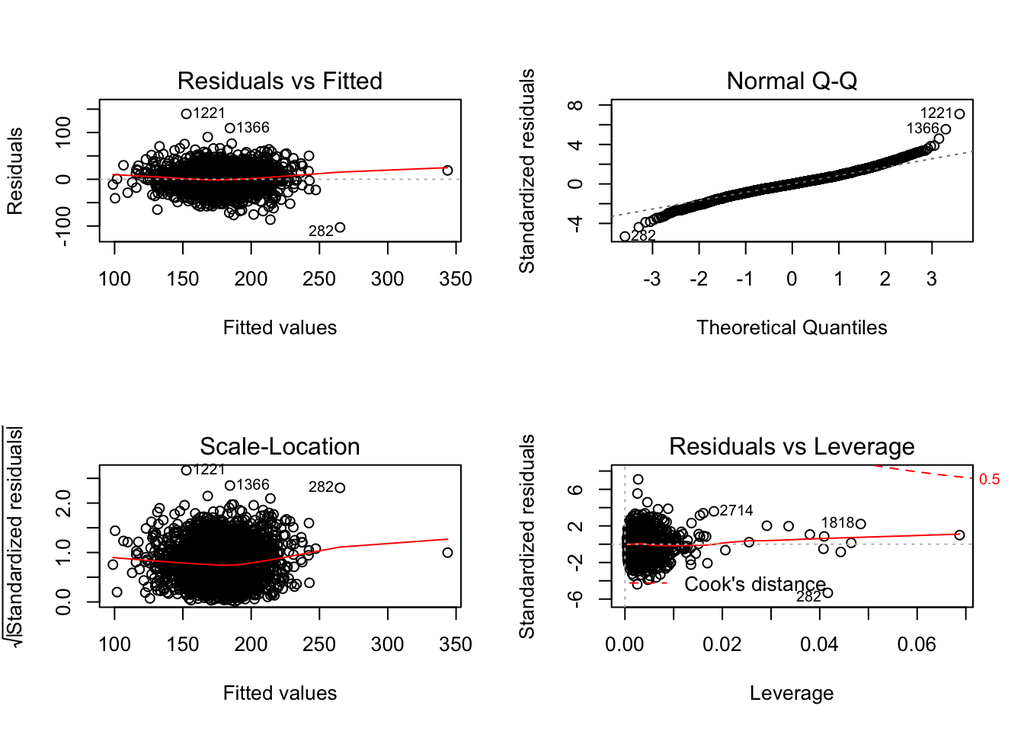

```r
par(mfrow = c(2, 2))
plot(model_7)
```

### Remove one outlier in y

```r
cancer_reg_remove =
  cancer_reg_tidy %>%
  filter(target_death_rate < 300)

model_remove = lm(formula = target_death_rate ~ incidence_rate + median_age_male + pct_hs18_24 + pct_bach_deg25_over + pct_public_coverage_alone + pct_other_race + pct_married_households, data = cancer_reg_remove)

summary(model_remove)
```

```
##
## Call:
## lm(formula = target_death_rate ~ incidence_rate + median_age_male +
##     pct_hs18_24 + pct_bach_deg25_over + pct_public_coverage_alone +
##     pct_other_race + pct_married_households, data = cancer_reg_remove)
##
## Residuals:
##      Min       1Q   Median       3Q      Max
## -101.990  -11.194   -0.291   11.284  139.960
##
## Coefficients:
##                            Estimate Std. Error t value Pr(>|t|)
## (Intercept)               135.82556    6.75929  20.095  < 2e-16 ***
## incidence_rate              0.19150    0.00706  27.127  < 2e-16 ***
## median_age_male            -0.50663    0.07508  -6.748 1.79e-11 ***
## pct_hs18_24                 0.35044    0.04474   7.833 6.55e-15 ***
## pct_bach_deg25_over        -1.63328    0.09101 -17.946  < 2e-16 ***
## pct_public_coverage_alone   0.76673    0.08791   8.722  < 2e-16 ***
## pct_other_race             -1.06375    0.10962  -9.704  < 2e-16 ***
## pct_married_households     -0.51089    0.06789  -7.526 6.87e-14 ***
## ---
## Signif. codes:  0 '***' 0.001 '**' 0.01 '*' 0.05 '.' 0.1 ' ' 1
##
## Residual standard error: 19.77 on 3038 degrees of freedom
## Multiple R-squared:  0.4866, Adjusted R-squared:  0.4854
## F-statistic: 411.4 on 7 and 3038 DF,  p-value: < 2.2e-16
```

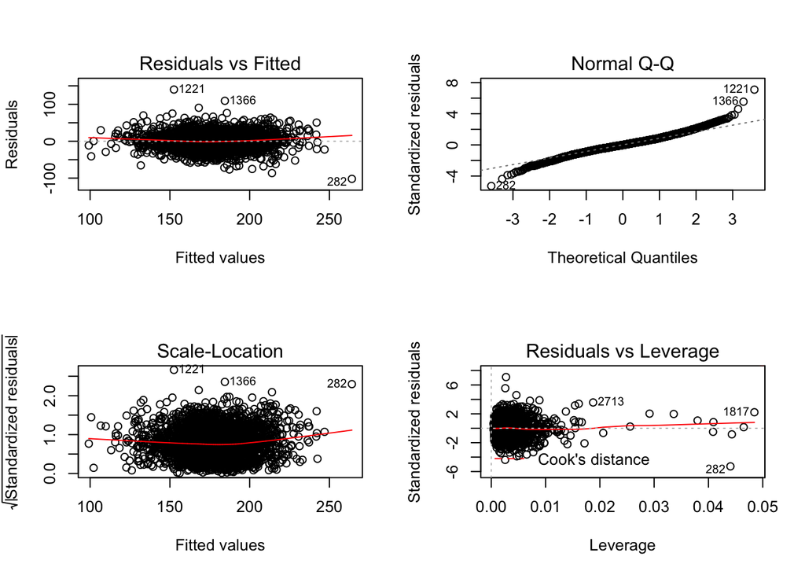

```r
par(mfrow = c(2, 2))
plot(model_remove)
```